# lec22_Octave

## 1D Random Walk

Let us consider a Bernoulli trial. In this, we will consider a bunch of particles at the origin. We will sample a random variable from [-1, +1] and then change the position of each particle. The feeling is that on an average, the particles will have a zero mean because the random variable drawn has zero mean. Let's see what the final distribution of the locations will be.

```matlab
set(0, "defaultlinelinewidth", 5);
set (0, "defaulttextfontname", "TimesNewRoman")
set (0, "defaulttextfontsize", 20)
set (0, "DefaultAxesFontName", "TimesNewRoman")
set(0, 'DefaultAxesFontSize', 20)
```

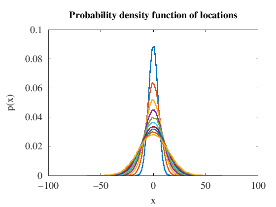

```matlab
function y=get_steps(N)
    y= randi ([0, 1], [N,1],"int8")*2-1;
end

Np = 100000; Nt = 200;
x = zeros(Np, Nt);

for i=2:1:Nt
    steps = get_steps(Np);
    x(:,i) = x(:,i-1) + steps;

    if (mod(i,20)==0)
        s = x(:,i);
        binsp = min(s):2:max(s);
        [counts, bins] = hist(s, binsp);
        plot(bins, counts/trapz(bins, counts));
        hold on;
    end
end
hold off;
xlabel('x'); ylabel('p(x)'); title('Probability density function of locations')
```

As can be seen, the distribution of the distances tends towards that of a bell-shaped curve. In fact this curve is the normal distribution. The fact that for large times, the distribution tends towards the normal distribution, is a consequence of the Central Limit Theorem. In this particular case, if the step sizes have a finite variance, then the eventual distribution tends towards the normal distribution. Let us now sample from a uniform distribution.

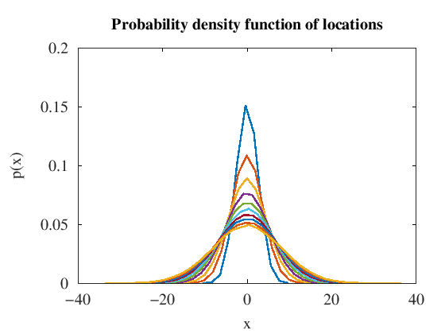

```matlab
pkg load statistics;
function y=get_steps(N)
    y=random("uniform",-1, 1, [N,1]);
end;
Np = 100000; Nt = 200;
x = zeros(Np, Nt);

for i=2:1:Nt
    steps = get_steps(Np);
    x(:,i) = x(:,i-1) + steps;

      if (mod(i,20)==0)
        s = x(:,i);
        binsp = min(s):2:max(s);
        [counts, bins] = hist(s, binsp);
        plot(bins, counts/trapz(bins, counts));
        hold on;
    end
end
hold off;
xlabel('x'); ylabel('p(x)'); title('Probability density function of locations')
```

Let us now see how the mean and variance scales with time.

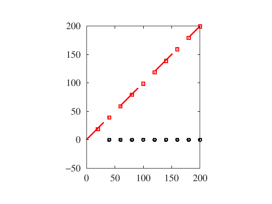

```matlab
function y=get_steps(N)
    #y= randi ([0, 1], [N,1],"int8")*2-1;
    y= random("uniform",-(3^0.5), 3^0.5, [N,1]);
end

Np = 100000; Nt = 200;
x = zeros(Np, Nt);

for i=2:1:Nt
    steps = get_steps(Np);
    x(:,i) = x(:,i-1) + steps;

    if (mod(i,20)==0)
        s = x(:,i);
        binsp = min(s):2:max(s);
        [counts, bins] = hist(s, binsp);
        counts = counts/trapz(bins, counts);
        m = trapz(bins(1:end), bins(1:end).*counts);
        var = trapz(bins(1:end), (bins(1:end)-m).^2.*counts);
        plot(i, m, 'ok');
        plot(i, var, 'sr');
        hold on;
    end
end

ta =0:1:Nt;
plot(ta, ta, '--r');
hold off;
daspect([1 1 1]);
```

The above plot clearly elucidates a very important property of the Central Limit Theorem. The variance seems to grow linearly with time.

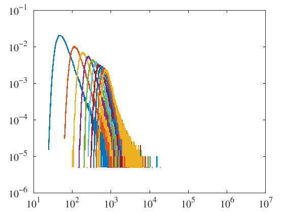

```matlab
warning('off', 'all'); # turn of warnings.

function y=get_steps(N,a,m)
    #y= randi ([0, 1], [N,1],"int8")*2-1;
    #y= random("uniform",-(3^0.5), 3^0.5, [N,1]);
    y = (1+burrrnd(1,1,a,[N,1]))*m;
end

Np = 100000; Nt = 200;
x = zeros(Np, Nt);

for i=2:1:Nt
    steps = get_steps(Np, 1.2, 1);
    x(:,i) = x(:,i-1) + steps;

    if (mod(i,20)==0)
        s = x(:,i);
        binsp = min(s):2:max(s);
        [counts, bins] = hist(s, binsp);
        counts = counts/trapz(bins, counts);
        loglog(bins, counts);
        hold on;
    end
end
hold off;
```

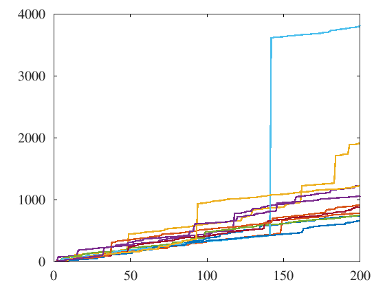

```matlab
for j=1:1:11
    plot(x(j,:));
    hold on;
end
hold off;
```